# Latent Variable

2023-11-20

The classic Holzinger and Swineford (1939) dataset consists of mental ability test scores of seventh- and eighth-grade children from two different schools (Pasteur and Grant-White). In the original dataset (available in the MBESS package), there are scores for 26 tests. However, a smaller subset with 9 variables is more widely used in the literature. Perform first an exploratory factor analysis and then a confirmatory factor analysis on this data set

```r
library(lavaan)
data(HolzingerSwineford1939)
?HolzingerSwineford1939
```

```
## avvio in corso del server httpd per la guida ...
```

```
##  fatto
```

x1 Visual perception x2 Cubes x3 Lozenges x4 Paragraph comprehension x5 Sentence completion x6 Word meaning x7 Speeded addition x8 Speeded counting of dots x9 Speeded discrimination straight and curved capitals

```r
head(HolzingerSwineford1939)
```

```
##   id sex ageyr agemo  school grade       x1   x2    x3       x4   x5        x6
## 1  1   1    13     1 Pasteur     7 3.333333 7.75 0.375 2.333333 5.75 1.2857143
## 2  2   2    13     7 Pasteur     7 5.333333 5.25 2.125 1.666667 3.00 1.2857143
## 3  3   2    13     1 Pasteur     7 4.500000 5.25 1.875 1.000000 1.75 0.4285714
## 4  4   1    13     2 Pasteur     7 5.333333 7.75 3.000 2.666667 4.50 2.4285714
## 5  5   2    12     2 Pasteur     7 4.833333 4.75 0.875 2.666667 4.00 2.5714286
## 6  6   2    14     1 Pasteur     7 5.333333 5.00 2.250 1.000000 3.00 0.8571429
##         x7   x8       x9
## 1 3.391304 5.75 6.361111
## 2 3.782609 6.25 7.916667
## 3 3.260870 3.90 4.416667
## 4 3.000000 5.30 4.861111
## 5 3.695652 6.30 5.916667
## 6 4.347826 6.65 7.500000
```

Var-cox matrix to see whether there is correlation among variables

```r
data<-HolzingerSwineford1939[,7:15]
matcor<-cor(data)
matcor
```

```
##            x1          x2         x3        x4         x5        x6          x7
## x1 1.00000000  0.29734551 0.44066800 0.3727063 0.29344369 0.3567702  0.06686392
## x2 0.29734551  1.00000000 0.33984898 0.1529302 0.13938749 0.1925319 -0.07566892
## x3 0.44066800  0.33984898 1.00000000 0.1586396 0.07719823 0.1976610  0.07193105
## x4 0.37270627  0.15293019 0.15863957 1.0000000 0.73317017 0.7044802  0.17382912
## x5 0.29344369  0.13938749 0.07719823 0.7331702 1.00000000 0.7199555  0.10204475
## x6 0.35677019  0.19253190 0.19766102 0.7044802 0.71995554 1.0000000  0.12110170
## x7 0.06686392 -0.07566892 0.07193105 0.1738291 0.10204475 0.1211017  1.00000000
## x8 0.22392677  0.09227923 0.18601263 0.1068984 0.13866998 0.1496113  0.48675793
## x9 0.39034041  0.20604057 0.32865061 0.2078483 0.22746642 0.2141617  0.34064572
##            x8        x9
## x1 0.22392677 0.3903404
## x2 0.09227923 0.2060406
## x3 0.18601263 0.3286506
## x4 0.10689838 0.2078483
## x5 0.13866998 0.2274664
## x6 0.14961132 0.2141617
## x7 0.48675793 0.3406457
## x8 1.00000000 0.4490154
## x9 0.44901545 1.0000000
```

how many factor? we start from one, then two and later see which is the best one.

### One factor Model

```r
f1<-factanal(~x1+x2+x3+x4+x5+x6+x7+x8+x9,data=data,1)
f2<-factanal(~x1+x2+x3+x4+x5+x6+x7+x8+x9,data=data,2)
f3<-factanal(~x1+x2+x3+x4+x5+x6+x7+x8+x9,data=data,3)
```

We compare the LRT of each model

```r
Chisq<-round(c(f1$STATISTIC,f2$STATISTIC,f3$STATISTIC),3)
Chisq
```

```
## objective objective objective
##   306.558   127.637    22.377
```

As the number of latents increases the d.f will decrease

```r
df<-c(f1$dof,f2$dof,f3$dof)
```

```r
p_value<-round(c(f1$PVAL,f2$PVAL,f3$PVAL),4)
p_value
```

```
## objective objective objective
##    0.0000    0.0000    0.0335
```

On the basis of the matrix of the factor loadings interpret the factors individuated, not all loading are displayed only those larger than 0.10, all loading can be see cutoff=0. We give factor 1 a label according to the variables that are more correlated with it (i.e x4,x5,x6), factor 2 is the one of visualisation ability, the third corresponds to the speed ability (i.e x7,x8,x7)

```r
loadings(f3)
```

```
##
## Loadings:
##    Factor1 Factor2 Factor3
## x1  0.277   0.623   0.151
## x2  0.105   0.489
## x3          0.663   0.130
## x4  0.827   0.165
## x5  0.861
## x6  0.801   0.212
## x7                  0.696
## x8          0.162   0.709
## x9  0.132   0.406   0.524
##
##                Factor1 Factor2 Factor3
## SS loadings      2.185   1.343   1.327
## Proportion Var   0.243   0.149   0.147
## Cumulative Var   0.243   0.392   0.539
```

Now the matrix of loading is similar to a simple matrix

```r
print(f3,cutoff=0.3)
```

```
##
## Call:
## factanal(x = ~x1 + x2 + x3 + x4 + x5 + x6 + x7 + x8 + x9, factors = 3,     data = data)
##
## Uniquenesses:
##    x1    x2    x3    x4    x5    x6    x7    x8    x9
## 0.513 0.749 0.543 0.279 0.243 0.305 0.502 0.469 0.543
##
## Loadings:
##    Factor1 Factor2 Factor3
## x1          0.623
## x2          0.489
## x3          0.663
## x4  0.827
## x5  0.861
## x6  0.801
## x7                  0.696
## x8                  0.709
## x9          0.406   0.524
##
##                Factor1 Factor2 Factor3
## SS loadings      2.185   1.343   1.327
## Proportion Var   0.243   0.149   0.147
## Cumulative Var   0.243   0.392   0.539
##
## Test of the hypothesis that 3 factors are sufficient.
## The chi square statistic is 22.38 on 12 degrees of freedom.
## The p-value is 0.0335
```

SS loadings 2.185, sum of the squared loading of the first factor and explains the variability explained by the first factor. Information about the general behavior.

```r
sum(loadings(f3)[,1]^2)
```

```
## [1] 2.184693
```

The overall variance is 9, 1*9 variables

```r
sum(loadings(f3)[,1]^2)/9
```

```
## [1] 0.2427436
```

We now want to compute the communalities by summing for each variable the corresponding loading

```r
comm<-rowSums(loadings(f3)^2)
comm
```

```
##        x1        x2        x3        x4        x5        x6        x7        x8
## 0.4874721 0.2512648 0.4572236 0.7208072 0.7571231 0.6947835 0.4977990 0.5314433
##        x9
## 0.4567549
```

percentage of the variance of the model is explained by the three-factor model

```r
percVar<-sum(comm)/9
percVar
```

```
## [1] 0.5394079
```

Same value found above Factor1 Factor2 Factor3 SS loadings 2.185 1.343 1.327 Proportion Var 0.243 0.149 0.147 Cumulative Var 0.243 0.392 0.539

### Residual Analysis

Outside of the main diagonal difference bwt R and ’ should be small Compute the reproduced correlation matrix and the discrepancy between the observed and reproduced correlation

```r
repcorr<-loadings(f3)%*%t(loadings(f3))
round(matcor-repcorr,3)
```

```
##        x1     x2     x3     x4     x5     x6     x7     x8     x9
## x1  0.513 -0.032 -0.001  0.026 -0.013 -0.011 -0.018  0.002  0.021
## x2 -0.032  0.749  0.015 -0.012  0.009  0.007 -0.031  0.027  0.007
## x3 -0.001  0.015  0.543  0.008 -0.021  0.018  0.026 -0.015 -0.013
## x4  0.026 -0.012  0.008  0.279 -0.002 -0.002  0.042 -0.032 -0.020
## x5 -0.013  0.009 -0.021 -0.002  0.243  0.004 -0.033  0.016  0.031
## x6 -0.011  0.007  0.018 -0.002  0.004  0.305  0.002  0.012 -0.024
## x7 -0.018 -0.031  0.026  0.042 -0.033  0.002  0.502  0.001 -0.006
## x8  0.002  0.027 -0.015 -0.032  0.016  0.012  0.001  0.469  0.005
## x9  0.021  0.007 -0.013 -0.020  0.031 -0.024 -0.006  0.005  0.543
```

On the main diagonal we have the uniqueness Off-diagonal we have a sort of residuals and indeed wwe want them to be small In this way we can see that the conditional independence condition actually holds and infer that the model is appropiate

###Rotation (only for explenatory analysis) We may want to apply rotation to get more interpretable factor models

```r
library(GPArotation)
Varimax(loadings(f3))
```

```
## Orthogonal rotation method varimax converged.
## Loadings:
##    Factor1 Factor2 Factor3
## x1  0.3202  0.1301  0.6066
## x2  0.1353 -0.0409  0.4809
## x3  0.0795  0.1133  0.6619
## x4  0.8379  0.0767  0.1131
## x5  0.8667  0.0703  0.0323
## x6  0.8151  0.0658  0.1617
## x7  0.1019  0.6954 -0.0624
## x8  0.0776  0.7036  0.1744
## x9  0.1699  0.5106  0.4088
##
##                Factor1 Factor2 Factor3
## SS loadings      2.290   1.286   1.279
## Proportion Var   0.254   0.143   0.142
## Cumulative Var   0.254   0.397   0.539
```

Here high correlation btw factor 1 and x4,x5,x6, …

```r
quartimax(loadings(f3))
```

```
## Orthogonal rotation method Quartimax converged.
## Loadings:
##    Factor1 Factor2 Factor3
## x1   0.353  0.1244  0.5897
## x2   0.158 -0.0423  0.4740
## x3   0.115  0.1140  0.6566
## x4   0.844  0.0557  0.0719
## x5   0.869  0.0483 -0.0102
## x6   0.823  0.0456  0.1215
## x7   0.116  0.6923 -0.0710
## x8   0.104  0.7021  0.1666
## x9   0.202  0.5078  0.3974
##
##                Factor1 Factor2 Factor3
## SS loadings      2.373   1.268   1.214
## Proportion Var   0.264   0.141   0.135
## Cumulative Var   0.264   0.404   0.539
```

Similar interpretation using quartimax

```r
oblimin(loadings(f3)) #oblique rotation
```

```
## Oblique rotation method Oblimin Quartimin converged.
## Loadings:
##    Factor1 Factor2  Factor3
## x1  0.1910  0.6020  0.03094
## x2  0.0437  0.5054 -0.11662
## x3 -0.0695  0.6893  0.02307
## x4  0.8405  0.0218  0.00531
## x5  0.8882 -0.0674  0.00756
## x6  0.8076  0.0775 -0.01093
## x7  0.0436 -0.1516  0.72310
## x8 -0.0327  0.1042  0.70150
## x9  0.0348  0.3661  0.46318
##
##                Factor1 Factor2 Factor3
## SS loadings      2.237   1.338   1.280
## Proportion Var   0.249   0.149   0.142
## Cumulative Var   0.249   0.397   0.539
##
## Phi:
##         Factor1 Factor2 Factor3
## Factor1   1.000   0.326   0.216
## Factor2   0.326   1.000   0.270
## Factor3   0.216   0.270   1.000
```

For the oblimin we also have the correlation matrix between factors and we may see that speed ability is correlated with visualisation ability.

### Factor Scores

Compute the factor scores using the Bartlett and the Thompson method

```r
fB = factanal(~x1+x2+x3+x4+x5+x6+x7+x8+x9,data=data,3,scores="Bartlett")$scores
```

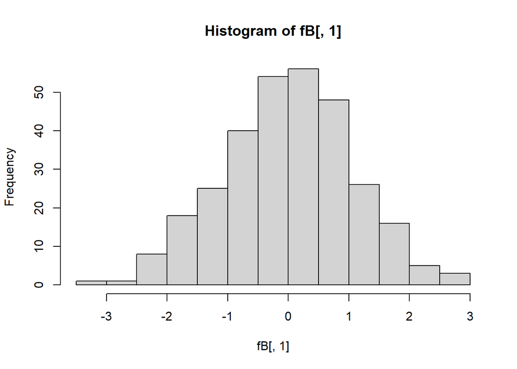

```r
hist(fB[,1])
```

We see a normal distribution, remember that this was however assumption

```r
fT<-factanal(~x1+x2+x3+x4+x5+x6+x7+x8+x9,data=data,3, scores="regression")$scores
head(fT)
```

```
##       Factor1    Factor2      Factor3
## 1  0.08247152 -0.7258616 -0.001591841
## 2 -1.21273720  0.5161999  0.822875023
## 3 -1.76841308 -0.2476878 -1.088698544
## 4 -0.04449707  0.7666871 -0.769782192
## 5 -0.06666738 -0.5306562  0.344127073
## 6 -1.53029546  0.3499646  1.148005610
```

### Confirmatory factor analysis

Here we confirm whether the model we have in mind is good or not visualisation is assumed to be measured by x1,x2,x3 and all other loading are fixed to 0, in the explenatory analysis all loading are computed. Chi-squared is multiplied by the sample size and so in confirmatory analysis using the chi-squared is not appropiate.

```r
HS.model <- 'visual  = ~ x1 + x2 + x3
             textual = ~x4 + x5 + x6
             speed   = ~x7 + x8 + x9'
fit <- cfa(HS.model, data=data) # ccfa stands for confermatory factor analysis
summary(fit,fit.measures=TRUE)  # =TRUE to visualise the goodness of fit measure
```

```
## lavaan 0.6.17 ended normally after 35 iterations
##
##   Estimator                                         ML
##   Optimization method                           NLMINB
##   Number of model parameters                        21
##
##   Number of observations                           301
##
## Model Test User Model:
##
##   Test statistic                                85.306
##   Degrees of freedom                                24
##   P-value (Chi-square)                           0.000
##
## Model Test Baseline Model:
##
##   Test statistic                               918.852
##   Degrees of freedom                                36
##   P-value                                        0.000
##
## User Model versus Baseline Model:
##
##   Comparative Fit Index (CFI)                    0.931
##   Tucker-Lewis Index (TLI)                       0.896
##
## Loglikelihood and Information Criteria:
##
##   Loglikelihood user model (H0)              -3737.745
##   Loglikelihood unrestricted model (H1)      -3695.092
##
##   Akaike (AIC)                                7517.490
##   Bayesian (BIC)                              7595.339
##   Sample-size adjusted Bayesian (SABIC)       7528.739
##
## Root Mean Square Error of Approximation:
##
##   RMSEA                                          0.092
##   90 Percent confidence interval - lower         0.071
##   90 Percent confidence interval - upper         0.114
##   P-value H_0: RMSEA <= 0.050                    0.001
```

[output cut: 34 more lines]

```
##
## Variances:
##                    Estimate  Std.Err  z-value  P(>|z|)
##    .x1                0.549    0.114    4.833    0.000
##    .x2                1.134    0.102   11.146    0.000
##    .x3                0.844    0.091    9.317    0.000
##    .x4                0.371    0.048    7.779    0.000
##    .x5                0.446    0.058    7.642    0.000
##    .x6                0.356    0.043    8.277    0.000
##    .x7                0.799    0.081    9.823    0.000
##    .x8                0.488    0.074    6.573    0.000
##    .x9                0.566    0.071    8.003    0.000
##     visual            0.809    0.145    5.564    0.000
##     textual           0.979    0.112    8.737    0.000
##     speed             0.384    0.086    4.451    0.000
```

From these measure we see that the model can be improved -it is good but not enough-

Latent Variables: Estimate Std.Err z-value P(>|z|) visual =~  
x1 1.000  
x2 0.554 0.100 5.554 0.000 x3 0.729 0.109 6.685 0.000 textual =~  
x4 1.000  
x5 1.113 0.065 17.014 0.000 x6 0.926 0.055 16.703 0.000 speed =~  
x7 1.000  
x8 1.180 0.165 7.152 0.000 x9 1.082 0.151 7.155 0.000

Ztest as we use asymptotic results, we fix one of the loading to 1

If we want instead to fix the variance to 1, easier way to analysis data

```r
fit <- cfa(HS.model, data = HolzingerSwineford1939, std.lv = TRUE)
summary(fit,fit.measures=TRUE)
```

```
## lavaan 0.6.17 ended normally after 20 iterations
##
##   Estimator                                         ML
##   Optimization method                           NLMINB
##   Number of model parameters                        21
##
##   Number of observations                           301
##
## Model Test User Model:
##
##   Test statistic                                85.306
##   Degrees of freedom                                24
##   P-value (Chi-square)                           0.000
##
## Model Test Baseline Model:
##
##   Test statistic                               918.852
##   Degrees of freedom                                36
##   P-value                                        0.000
##
## User Model versus Baseline Model:
##
##   Comparative Fit Index (CFI)                    0.931
##   Tucker-Lewis Index (TLI)                       0.896
##
## Loglikelihood and Information Criteria:
##
##   Loglikelihood user model (H0)              -3737.745
##   Loglikelihood unrestricted model (H1)      -3695.092
##
##   Akaike (AIC)                                7517.490
##   Bayesian (BIC)                              7595.339
##   Sample-size adjusted Bayesian (SABIC)       7528.739
##
## Root Mean Square Error of Approximation:
##
##   RMSEA                                          0.092
##   90 Percent confidence interval - lower         0.071
##   90 Percent confidence interval - upper         0.114
##   P-value H_0: RMSEA <= 0.050                    0.001
```

[output cut: 34 more lines]

```
##
## Variances:
##                    Estimate  Std.Err  z-value  P(>|z|)
##    .x1                0.549    0.114    4.833    0.000
##    .x2                1.134    0.102   11.146    0.000
##    .x3                0.844    0.091    9.317    0.000
##    .x4                0.371    0.048    7.779    0.000
##    .x5                0.446    0.058    7.642    0.000
##    .x6                0.356    0.043    8.277    0.000
##    .x7                0.799    0.081    9.823    0.000
##    .x8                0.488    0.074    6.573    0.000
##    .x9                0.566    0.071    8.003    0.000
##     visual            1.000
##     textual           1.000
##     speed             1.000
```

looking at the matrix of loading, x9 high correlated with factor 2

```r
print(f3,cutoff=0.3)
```

```
##
## Call:
## factanal(x = ~x1 + x2 + x3 + x4 + x5 + x6 + x7 + x8 + x9, factors = 3,     data = data)
##
## Uniquenesses:
##    x1    x2    x3    x4    x5    x6    x7    x8    x9
## 0.513 0.749 0.543 0.279 0.243 0.305 0.502 0.469 0.543
##
## Loadings:
##    Factor1 Factor2 Factor3
## x1          0.623
## x2          0.489
## x3          0.663
## x4  0.827
## x5  0.861
## x6  0.801
## x7                  0.696
## x8                  0.709
## x9          0.406   0.524
##
##                Factor1 Factor2 Factor3
## SS loadings      2.185   1.343   1.327
## Proportion Var   0.243   0.149   0.147
## Cumulative Var   0.243   0.392   0.539
##
## Test of the hypothesis that 3 factors are sufficient.
## The chi square statistic is 22.38 on 12 degrees of freedom.
## The p-value is 0.0335
```

Better results, so x9 is both an indicator both visual and speed ability

```r
HS.model <- 'visual  = ~ x1 + x2 + x3 +x9
             textual = ~x4 + x5 + x6
             speed   = ~x7 + x8 + x9'
fit <- cfa(HS.model, data=data) # ccfa stands for confermatory factor analysis
summary(fit,fit.measures=TRUE)  # =TRUE to visualise the goodness of fit measure
```

```
## lavaan 0.6.17 ended normally after 34 iterations
##
##   Estimator                                         ML
##   Optimization method                           NLMINB
##   Number of model parameters                        22
##
##   Number of observations                           301
##
## Model Test User Model:
##
##   Test statistic                                52.382
##   Degrees of freedom                                23
##   P-value (Chi-square)                           0.000
##
## Model Test Baseline Model:
##
##   Test statistic                               918.852
##   Degrees of freedom                                36
##   P-value                                        0.000
##
## User Model versus Baseline Model:
##
##   Comparative Fit Index (CFI)                    0.967
##   Tucker-Lewis Index (TLI)                       0.948
##
## Loglikelihood and Information Criteria:
##
##   Loglikelihood user model (H0)              -3721.283
##   Loglikelihood unrestricted model (H1)      -3695.092
##
##   Akaike (AIC)                                7486.566
##   Bayesian (BIC)                              7568.123
##   Sample-size adjusted Bayesian (SABIC)       7498.351
##
## Root Mean Square Error of Approximation:
##
##   RMSEA                                          0.065
##   90 Percent confidence interval - lower         0.042
##   90 Percent confidence interval - upper         0.089
##   P-value H_0: RMSEA <= 0.050                    0.133
```

[output cut: 35 more lines]

```
##
## Variances:
##                    Estimate  Std.Err  z-value  P(>|z|)
##    .x1                0.576    0.100    5.731    0.000
##    .x2                1.120    0.100   11.153    0.000
##    .x3                0.830    0.087    9.515    0.000
##    .x9                0.558    0.060    9.336    0.000
##    .x4                0.373    0.048    7.800    0.000
##    .x5                0.444    0.058    7.602    0.000
##    .x6                0.357    0.043    8.285    0.000
##    .x7                0.740    0.086    8.595    0.000
##    .x8                0.375    0.094    3.973    0.000
##     visual            0.783    0.134    5.842    0.000
##     textual           0.978    0.112    8.728    0.000
##     speed             0.444    0.097    4.567    0.000
```

DOES IS MAKE SENSE TO PERFORM THE COMMUNALITIES???

### Model with Uncorrelation btw latent variables

We can notice that this model in not adequate and worse

```r
fit.HS.ortho <- cfa(HS.model, data = HolzingerSwineford1939, orthogonal= TRUE)
summary(fit.HS.ortho)
```

```
## lavaan 0.6.17 ended normally after 31 iterations
##
##   Estimator                                         ML
##   Optimization method                           NLMINB
##   Number of model parameters                        19
##
##   Number of observations                           301
##
## Model Test User Model:
##
##   Test statistic                               106.240
##   Degrees of freedom                                26
##   P-value (Chi-square)                           0.000
##
## Parameter Estimates:
##
##   Standard errors                             Standard
##   Information                                 Expected
##   Information saturated (h1) model          Structured
##
## Latent Variables:
##                    Estimate  Std.Err  z-value  P(>|z|)
##   visual =~
##     x1                1.000
##     x2                0.704    0.120    5.885    0.000
##     x3                0.940    0.140    6.709    0.000
##     x9                0.554    0.092    6.022    0.000
##   textual =~
##     x4                1.000
##     x5                1.133    0.067   16.906    0.000
##     x6                0.924    0.056   16.391    0.000
##   speed =~
##     x7                1.000
##     x8                1.056    0.164    6.431    0.000
##     x9                0.697    0.104    6.679    0.000
##
## Covariances:
##                    Estimate  Std.Err  z-value  P(>|z|)
##   visual ~~
##     textual           0.000
##     speed             0.000
##   textual ~~
##     speed             0.000
##
## Variances:
##                    Estimate  Std.Err  z-value  P(>|z|)
##    .x1                0.737    0.104    7.113    0.000
##    .x2                1.073    0.101   10.604    0.000
##    .x3                0.726    0.096    7.594    0.000
##    .x9                0.525    0.063    8.359    0.000
##    .x4                0.382    0.049    7.805    0.000
##    .x5                0.416    0.059    7.038    0.000
##    .x6                0.369    0.044    8.367    0.000
##    .x7                0.676    0.091    7.404    0.000
##    .x8                0.457    0.089    5.113    0.000
##     visual            0.621    0.126    4.946    0.000
##     textual           0.969    0.112    8.640    0.000
##     speed             0.507    0.108    4.713    0.000
```